# Лабораторная работа №1

Компьютерный практикум по статистическому анализу данных

Лисенков Е.Р.

Российский университет дружбы народов, Москва, Россия

# Информация

## Докладчик

- Лисенков Егор Романович
- студент НФИбд-02-23
- Российский университет дружбы народов
- 1132232881@rudn.ru
- https://github.com/erlisenkov

# Вводная часть

## Актуальность

Подготовка воспроизводимого вычислительного окружения на базе языка Julia и интерактивной среды Jupyter Lab является фундаментом для современного научного программирования и статистического анализа данных.

## Объект и предмет исследования

Объектом является инструментарий вычислительного эксперимента на языке Julia, а предметом — настройка рабочего пространства, интеграция с Git/GitHub и освоение базового синтаксиса языка.

## Цели и задачи

Целью работы выступает подготовка окружения для курса компьютерного практикума, а задачами — установка Julia и Jupyter, настройка репозитория по шаблону курса и выполнение примеров базового синтаксиса.

## Материалы и методы

Работа выполнена в ОС Fedora Linux с использованием пакетного менеджера dnf, установщика juliaup, среды Jupyter Lab, системы контроля версий Git и утилиты GitHub CLI.

## Обновление системы и установка средств разработки

Выполнено обновление репозиториев Fedora и установка базовых инструментов разработки: git, curl, gcc и make, необходимых для сборки пакетов Julia.

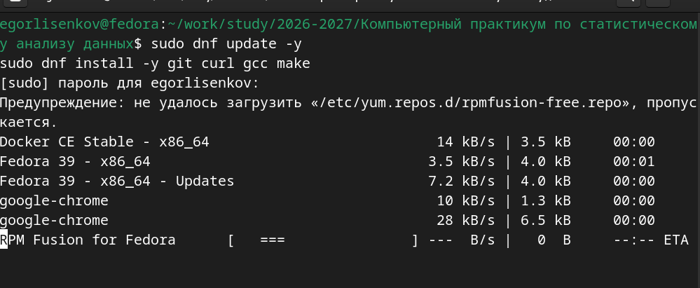

## Установка Julia через официальный скрипт

С помощью утилиты curl загружен и выполнен установочный скрипт julialang.org, который автоматически развернул менеджер версий juliaup.

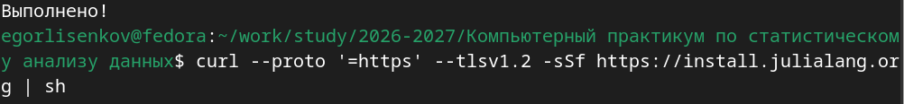

## Проверка версии установленной Julia

Команда julia –version подтвердила успешную установку интерпретатора Julia версии 1.10.3, готового к работе в командной строке.

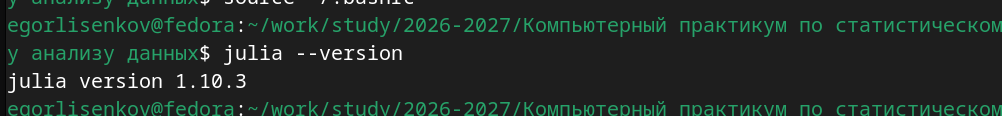

## Установка Python 3 и pip

Через пакетный менеджер dnf установлены интерпретатор Python 3 и пакетный менеджер pip, необходимые для последующего развёртывания Jupyter Lab.

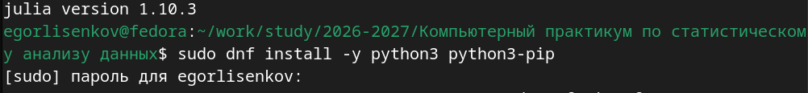

## Подготовка к установке Jupyter Lab

Система проверила наличие зависимостей и подтвердила, что Jupyter Lab уже установлен в стандартных путях Python, что позволяет перейти к настройке ядра Julia.

[figure not shown]

## Настройка Git и проверка авторизации GitHub CLI

Заданы глобальные параметры пользователя Git, а команда gh auth status подтвердила успешный вход в аккаунт GitHub с правами доступа к репозиториям.

[figure not shown]

## Создание репозитория из шаблона через GitHub CLI

[figure not shown]

## Установка пакета IJulia для интеграции с Jupyter

В интерактивном режиме REPL Julia выполнен запуск пакетного менеджера Pkg и установка библиотеки IJulia, обеспечивающей связь между Julia и Jupyter Lab.

[figure not shown]

## Клонирование репозитория курса на локальную машину

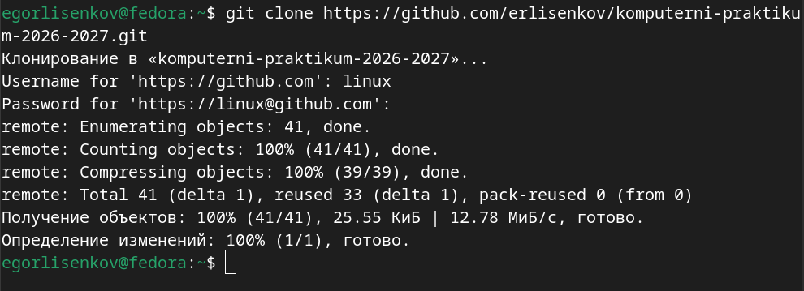

## Проверка установки Jupyter Lab

Команда pip3 install jupyterlab подтвердила наличие всех необходимых компонентов интерактивной среды в системе, завершив этап подготовки инструментария.

[figure not shown]

## Проверка статуса Git и обнаружение неотслеживаемых файлов

Команда git status выявила новые файлы Project.toml и каталог labs/, требующие добавления в индекс для фиксации структуры проекта в системе контроля версий.

[figure not shown]

## Выполнение заданий лабораторной работы в Jupyter Lab

В блокноте lab01.ipynb реализованы примеры определения типов, диапазонов целых чисел, преобразования типов, функций и операций с массивами согласно методическим указаниям.

[figure not shown]

## Фиксация изменений в Git и отправка на GitHub

После добавления файлов в индекс и создания коммита изменения успешно отправлены в удалённый репозиторий, несмотря на первоначальную ошибку именования ветки.

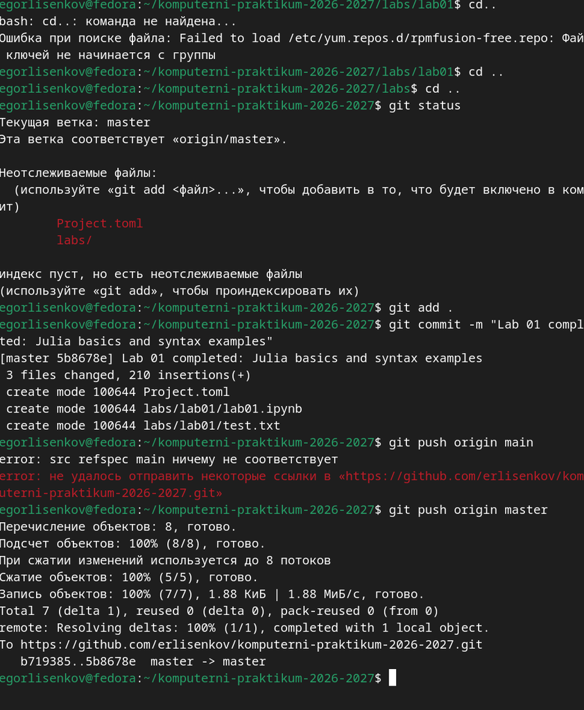

## Выводы

В результате выполнения лабораторной работы №1 были освоены базовые навыки работы с языком программирования Julia и интерактивной средой Jupyter Lab. Практически подтверждена простота и выразительность синтаксиса Julia для численных вычислений: автоматический вывод типов, множественная диспетчеризация, встроенная поддержка комплексных чисел и математических констант, удобные операции с массивами и матрицами без необходимости явного импорта библиотек.